# Food Safety in Africa

Yunting

4/30/2020

# 1 - Team Members

- [**Yunting Chiu**](https://www.linkedin.com/in/yuntingchiu)
  - tidy data, statistical analysis, project management, data mapping, data visualization.
- **Kingsley Ofoegbu**
  - data analysis, data-driven hypotheses, data visualization, report writing, tidy data, regression.
- **Shan Lin**
  - report writing, literature review, data evaluation.
- **Doudou Shi**
  - report writing, data visualization, data analysis, statistical analysis.

# 2 - Introduction

In this project, we hope to answer certain questions with the data set we have and proffer possible solutions to bring about better Food security in Africa.

After this, we should be able to comfortably suggest measures to counter the gaping holes in infrastructure, food supply, hazard control and questions that need answering.

The analysis is based on Global Food Safety Partnerships (GFSP) dataset from 49 countries between 2006 to 2017. We are interested in quantitative measurement for this project, especially we compared Africa’s GDP and total population.

# 3 - Data Cleaning

### 3.1 - Loading Libraries

library(tidyverse)  
library(dplyr)  
library(readxl)  
library(readr)  
library(ggplot2)  
library(spData)  
library(ggthemes)  
library(sf)  
library(knitr)  
library(rnaturalearth)  
library(rnaturalearthdata)  
library(rgeos)  
library(ggspatial)  
library(lwgeom)

# 3 - Data Cleaning

### 3.2 - Load the data first, and reformating features

```
## # A tibble: 518 x 153
##    `ID number` `Both lab` `# Country/proj… Training Category `A (MY FS), B (…
##    <chr>            <dbl>            <dbl>    <dbl> <fct>    <chr>
##  1 AESA-1               0                4        0 1        A
##  2 AfDB-1               2                5        2 2        B
##  3 AfDB-2               0                1        0 2        B
##  4 AfDB-3               0                1        1 2        B
##  5 AfDB-4               0                1        1 2        B
##  6 AfDB-5               0                0        0 2        B
##  7 AfDB-6               0                1        1 2        B
##  8 AfDB-7               2                1        2 2        B
##  9 AgResults-1          0                1        1 1        A
## 10 ASTF-1               0                8        1 2        B
## # … with 508 more rows, and 147 more variables: A1_DonorName <chr>,
## #   A2_Agency <chr>, A3_DonorCat <fct>, Program <chr>, A4_Project <chr>,
## #   A5_Statement <chr>, A6_Keywords <chr>, A7_ImplOrg <chr>, A8_ImplCat <fct>,
## #   A9_ANGOLA <dbl>, A9_BENIN <dbl>, A9_BOTSWANA <dbl>, `A9_BURKINA
## #   FASO` <dbl>, A9_BURUNDI <dbl>, `A9_CABO VERDE` <dbl>, A9_CAMEROON <dbl>,
## #   A9_CAR <dbl>, A9_CHAD <dbl>, A9_COMOROS <dbl>, A9_CONGO <dbl>, `A9_COTE
## #   D'IVOIRE` <dbl>, A9_DRC <dbl>, A9_DJIBOUTI <dbl>, `A9_EQ GUINEA` <dbl>,
## #   A9_ERITREA <dbl>, A9_ETHIOPIA <dbl>, A9_GABON <dbl>, A9_GAMBIA <dbl>,
## #   A9_GHANA <dbl>, A9_GUINEA <dbl>, `A9_GUINEA-BISSAU` <dbl>, A9_KENYA <dbl>,
## #   A9_LESOTHO <dbl>, A9_LIBERIA <dbl>, A9_MADAGASCAR <dbl>, A9_MALAWI <dbl>,
## #   A9_MALI <dbl>, A9_MAURITANIA <dbl>, A9_MAURITIUS <dbl>,
## #   A9_MOZAMBIQUE <dbl>, A9_NAMIBIA <dbl>, A9_NIGER <dbl>, A9_NIGERIA <dbl>,
## #   A9_RWANDA <dbl>, `A9_SAO TOME AND PRINCIPE` <dbl>, A9_SENEGAL <dbl>,
## #   A9_SEYCHELLES <dbl>, `A9_SIERRA LEONE` <dbl>, A9_SOMALIA <dbl>, `A9_SOUTH
## #   AFRICA` <dbl>, `A9_SOUTH SUDAN` <dbl>, A9_SUDAN <dbl>, A9_SWAZILAND <dbl>,
## #   A9_TOGO <dbl>, A9_UGANDA <dbl>, A9_TANZANIA <dbl>, A9_ZAMBIA <dbl>,
## #   A9_ZIMBABWE <dbl>, A9a_Level <dbl>, A10_REC <dbl>, A10_REC2 <dbl>,
## #   A11_YearInit <dbl>, A12_YearEnd <dbl>, A13_TimeFrame <dbl>,
## #   A14_LimitedRequest <dbl>, A15_OtherCharacteristics <dbl>, `B1_Project
## #   focus` <fct>, B2_Purpose_P <dbl>, B3_Purpose_S <dbl>, B4_Activity_1 <dbl>,
## #   B4_Activity_2 <dbl>, B4_Activity_3 <dbl>, B4_Activity_4 <dbl>,
## #   B4_Activity_5 <dbl>, B4_Activity_6 <dbl>, B4_Activity_7 <dbl>,
## #   B4_Activity_8 <dbl>, B4_Activity_9 <dbl>, B4_Activity_10 <dbl>,
## #   B4_Activity_11 <dbl>, B4_Activity_12 <dbl>, B4_Activity_13 <dbl>,
## #   B4_Activity_14 <dbl>, B4_Activity_15 <dbl>, B4_Activity_16 <dbl>,
## #   B4_Activity_17 <dbl>, B5_MarketFocus <dbl>, B6_InformalMarkets <dbl>,
## #   C1_HazardCat_Mycotoxins <dbl>, C1_HazardCat_Microbiological <dbl>,
## #   C1_HazardCat_NatChemical <dbl>, C1_HazardCat_ManChem <dbl>,
## #   C1_HazardCat_Unspecified <dbl>, C2_HazardName <chr>,
## #   C3_CommodityCat_1 <dbl>, C3_CommodityCat_2 <dbl>, C3_CommodityCat_3 <dbl>,
## #   C3_CommodityCat_4 <dbl>, C3_CommodityCat_5 <dbl>, C3_CommodityCat_6 <dbl>,
## #   …
```

# 3 - Data Cleaning

### 3.3 - Reshaping with multiple columns

- pivot_longer for each part.(A9, B4, C1, C3, D2, D4, D6, Running in)
- filter( != 0)
- list(factor())
- use pipe(%>%) to make connections.

```
## # A tibble: 171,379 x 55
##    `ID number` `Both lab` `# Country/proj… Training Category `A (MY FS), B (…
##    <chr>            <dbl>            <dbl>    <dbl> <fct>    <chr>
##  1 AESA-1               0                4        0 1        A
##  2 AESA-1               0                4        0 1        A
##  3 AESA-1               0                4        0 1        A
##  4 AESA-1               0                4        0 1        A
##  5 AESA-1               0                4        0 1        A
##  6 AESA-1               0                4        0 1        A
##  7 AESA-1               0                4        0 1        A
##  8 AESA-1               0                4        0 1        A
##  9 AESA-1               0                4        0 1        A
## 10 AESA-1               0                4        0 1        A
## # … with 171,369 more rows, and 49 more variables: A1_DonorName <chr>,
## #   A2_Agency <chr>, A3_DonorCat <fct>, Program <chr>, A4_Project <chr>,
## #   A5_Statement <chr>, A6_Keywords <chr>, A7_ImplOrg <chr>, A8_ImplCat <fct>,
## #   A9a_Level <dbl>, A10_REC <dbl>, A10_REC2 <dbl>, A11_YearInit <dbl>,
## #   A12_YearEnd <dbl>, A13_TimeFrame <dbl>, A14_LimitedRequest <dbl>,
## #   A15_OtherCharacteristics <dbl>, `B1_Project focus` <fct>,
## #   B2_Purpose_P <dbl>, B3_Purpose_S <dbl>, B5_MarketFocus <dbl>,
## #   B6_InformalMarkets <dbl>, C2_HazardName <chr>, C4_CommodityName <chr>,
## #   C5_ValueChain <chr>, D1_VCParticipantsNames <chr>, D3_DonorPartNames <chr>,
## #   `D5_Non-DonorPartNames` <chr>, E1_Total_Budget <dbl>, E2_FSBudget <dbl>,
## #   E3_BudgetCat <fct>, `Long-term project` <dbl>, `Short-term
## #   project/TA` <dbl>, Country <chr>, project_role <dbl>, Activity <chr>,
## #   activity_type <dbl>, Hazard_cat <chr>, hazard_type <dbl>,
## #   Commodity_cat <chr>, commodity_type <dbl>, Value_chain <chr>,
## #   value_part <dbl>, Donor_cat <chr>, Donor_part <dbl>, NonDonor_cat <chr>,
## #   NonDonor_part <dbl>, Years_Ran <chr>, Times_Ran <dbl>
```

# 3 - Data Cleaning

### 3.4 - rename the data frame

- Country
- B1_Project_focus
- Total_budget_USD
- A8_ImplCat
- A13_TimeFrame
- Activity
- Commodity_cat
- Donor_cat
- NonDonor_cat

```
## # A tibble: 10 x 55
##    ID_number `Both lab` `# Country/proj… Training Category `A (MY FS), B (…
##    <fct>          <dbl>            <dbl>    <dbl> <fct>    <chr>
##  1 US-10              2                4        1 2        B
##  2 EC-44              2                1        2 1        A
##  3 EC-37              2                1        2 1        A
##  4 EC-39              2                1        2 1        A
##  5 US-10              2                4        1 2        B
##  6 US-10              2                4        1 2        B
##  7 EC-44              2                1        2 1        A
##  8 EC-35              2                1        2 1        A
##  9 EC-50              2               16        2 1        A
## 10 EC-38              2                1        2 1        A
## # … with 49 more variables: A1_DonorName <chr>, A2_Agency <chr>,
## #   A3_DonorCat <fct>, Program <chr>, A4_Project <chr>, A5_Statement <chr>,
## #   A6_Keywords <chr>, A7_ImplOrg <chr>, A8_ImplCat <fct>, A9a_Level <dbl>,
## #   A10_REC <dbl>, A10_REC2 <dbl>, A11_YearInit <dbl>, A12_YearEnd <dbl>,
## #   A13_TimeFrame <chr>, A14_LimitedRequest <dbl>,
## #   A15_OtherCharacteristics <dbl>, B1_Project_focus <fct>, B2_Purpose_P <dbl>,
## #   B3_Purpose_S <dbl>, B5_MarketFocus <dbl>, B6_InformalMarkets <dbl>,
## #   C2_HazardName <chr>, C4_CommodityName <chr>, C5_ValueChain <chr>,
## #   D1_VCParticipantsNames <chr>, D3_DonorPartNames <chr>,
## #   `D5_Non-DonorPartNames` <chr>, Total_budget_USD <dbl>, E2_FSBudget <dbl>,
## #   E3_BudgetCat <fct>, `Long-term project` <dbl>, `Short-term
## #   project/TA` <dbl>, Country <fct>, project_role <dbl>, Activity <chr>,
## #   activity_type <dbl>, Hazard_cat <chr>, hazard_type <dbl>,
## #   Commodity_cat <chr>, commodity_type <dbl>, Value_chain <chr>,
## #   value_part <dbl>, Donor_cat <chr>, Donor_part <dbl>, NonDonor_cat <chr>,
## #   NonDonor_part <dbl>, Years_Ran <chr>, Times_Ran <dbl>
```

# 3 - Data Cleaning

### 3.5 - select the columns

- Country: Country name
- A8_ImplCat: Implementing organization category
- A11_YearInit: Year initiated
- A12_YearEnd: Year end
- A13_TimeFrame: Time frame of project/activity(If completed in 1 year or less)
- Activity: project activity
- Commodity_cat: Commodity category
- Donor_cat: Donor partner categories
- NonDonor_cat: Non-donor partner names
- Total_budget_USD: Total budget of project or activity (USD)
- E2_FSBudget: Estimated total budget of food safety activities (USD) within project
- Category: Category 1 and Category 2
- Hazard_cat: Hazard Category

```
## # A tibble: 5 x 13
##   Country A8_ImplCat A11_YearInit A12_YearEnd A13_TimeFrame Activity
##   <fct>   <fct>             <dbl>       <dbl> <chr>         <chr>
## 1 SOUTH … NGO                2008        2011 <NA>          Staff t…
## 2 NIGERIA Multilate…         2015        2016 >= 31 days    Staff t…
## 3 CAMERO… NGO                2009        2015 <NA>          Extensi…
## 4 TOGO    NGO                2009        2015 <NA>          Traceab…
## 5 MALAWI  Government         2010        2017 <NA>          Legisla…
## # … with 7 more variables: Commodity_cat <chr>, Donor_cat <chr>,
## #   NonDonor_cat <chr>, Total_budget_USD <dbl>, E2_FSBudget <dbl>,
## #   Category <fct>, Hazard_cat <chr>
```

# 4 - Initial Hypotheses

- 4.1.1 Which countries are funded the most and the least?
- Budget vs Number of project in each Country
- 4.1.3 - Distribution projects in respect of the country

# 4.1.1 Which countries are funded the most and the least?

```
## # A tibble: 1 x 3
##   Country total_budget project
##   <chr>          <dbl>   <int>
## 1 ZAMBIA    731977868.      48
```

```
## # A tibble: 1 x 3
##   Country   total_budget project
##   <chr>            <dbl>   <int>
## 1 EQ GUINEA            0       1
```

# 4.1.2 Budget vs Number of project in each Country

- Here we create scatter plots and box plots to ascertain if there is a linear relationship.
- Number of projects done per country and Total Funds allocated per country, from this scatter plot. we can see that the countries that got more fundings had more projects, there is a linear relationship between if a country gets more funding.

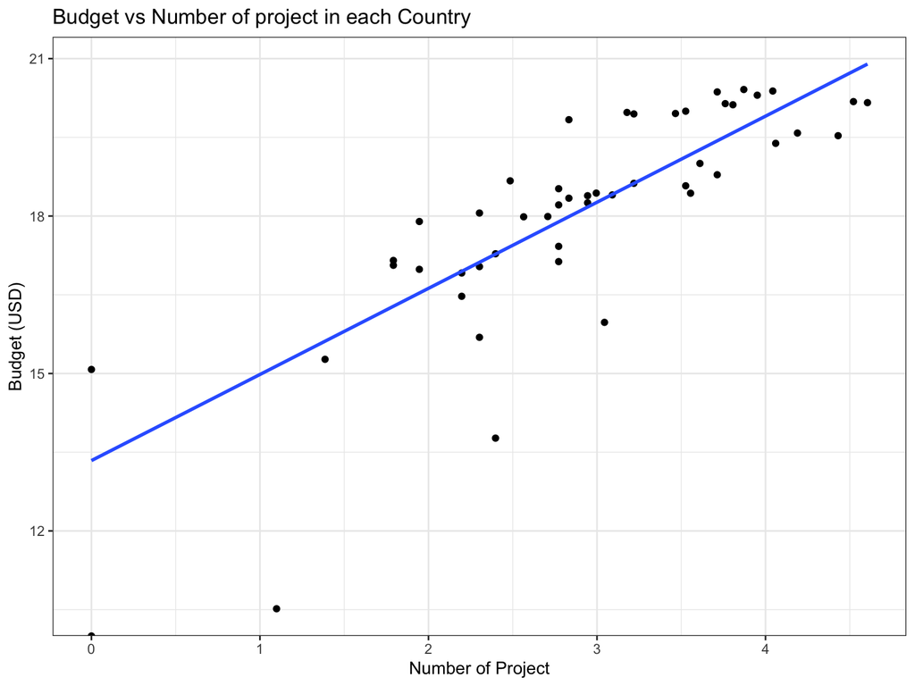

# 4.1.3 - Distribution projects in respect of the country

- we can see each country of project type.

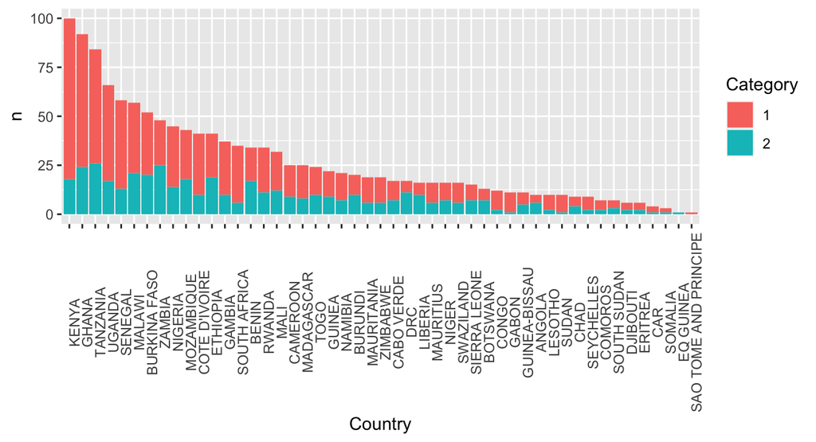

# 5 - Exploratory Data Analysis

- 5.1 - Datasets  
  ** 5.1.1 - which country involved in the project?
- 5.2 - Data Visualization  
  ** 5.2.1 - Drawing Africa maps programmatically  
  ** 5.2.2 - The rate at with hazard affects food security in africa in each country  
  ** 5.2.3 - Showed the commodity list with each country.
- 5.3 - Statistical Inference  
  ** 5.3.1 - Calculate the positive correlation with medians of Africa population and the Food Safety project.  
  ** 5.2.3 - Showed the commodity list with each country.  
  ** 5.3.2 - Does international investment in food in African countries affect local GDP?

# 5.1 - Datasets

# 5.1.1 - which country involved in the project?

- 49 countries

```
## # A tibble: 6 x 3
##   Country      total_budget project
##   <chr>               <dbl>   <int>
## 1 zambia         731977868.      48
## 2 malawi         711182036.      57
## 3 ethiopia       699045635.      41
## 4 burkina faso   656849670.      52
## 5 ghana          581190633.      92
## 6 kenya          569921505.     100
```

# 5.2 - Data Visualization

# 5.2.1 - Drawing Africa maps programmatically

- Obviously, the Africa map is easy to let readers know the association between the number of aid programs and each country.

```
## # A tibble: 24 x 2
##    Country                          name
##    <chr>                            <chr>
##  1 ALGERIA                          Algeria
##  2 CABO VERDE                       <NA>
##  3 CAPE VERDE                       Cape Verde
##  4 CAR                              <NA>
##  5 CENTRAL AFRICAN REPUBLIC         Central African Rep.
##  6 CONGO                            <NA>
##  7 COTE D'IVOIRE                    <NA>
##  8 DEMOCRATIC REPUBLIC OF THE CONGO Dem. Rep. Congo
##  9 DRC                              <NA>
## 10 EGYPT                            Egypt
## # … with 14 more rows
```

```
## # A tibble: 8 x 2
##   Country        name
##   <chr>          <chr>
## 1 ALGERIA        Algeria
## 2 EGYPT          Egypt
## 3 LIBYA          Libya
## 4 MOROCCO        Morocco
## 5 SAINT HELENA   Saint Helena
## 6 SOMALILAND     Somaliland
## 7 TUNISIA        Tunisia
## 8 WESTERN SAHARA W. Sahara
```

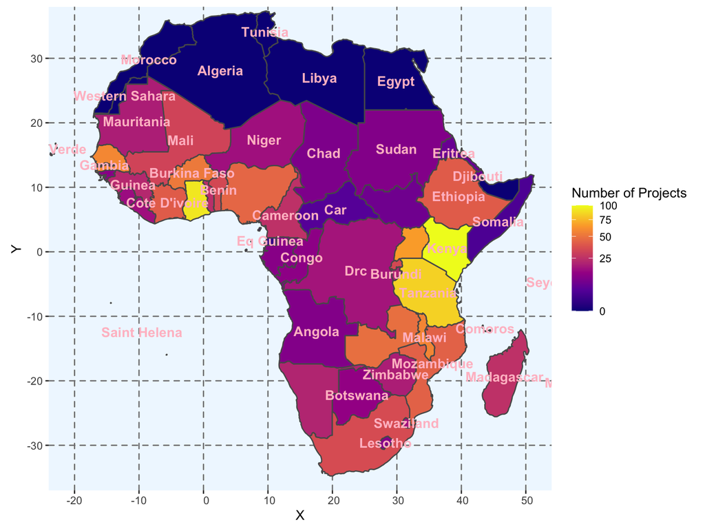

# 5.2.2 - The rate at with hazard affects food security in africa in each country

- Here we know that different hazards affects different crops but what are those hazards and how much do they affect security in each country, this shows just that and with it organizations would know how to tailor their plans for specific countries.

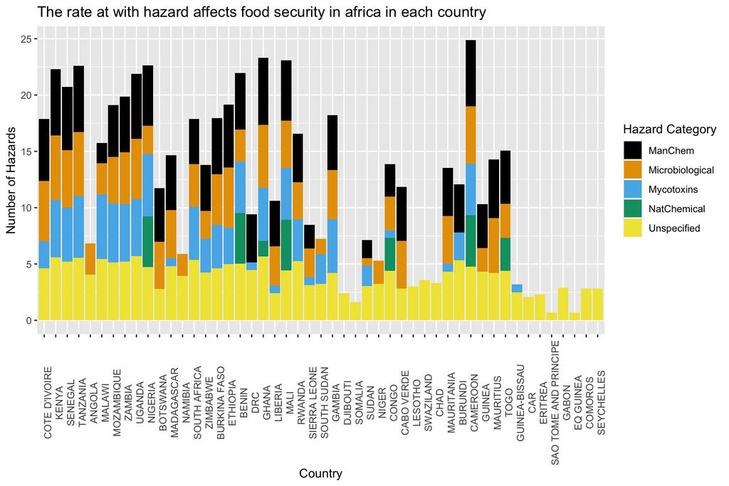

# 5.2.3 - Showed the commodity list with each country.

- Here we want to find out which country receives what type of commodity the most.

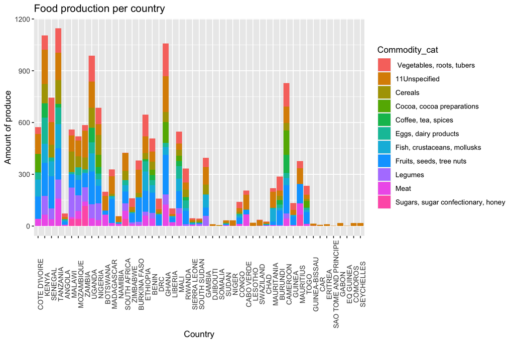

# 5.3 - Statistical Inference

# 5.3.1 - Calculate the positive correlation with medians of Africa population and the Food Safety project.

- As the project start years are between 2006 to 2018(removed NA). In this case, we download the 2006-2018 Africa area total population from UN data to compare it.

```
## # A tibble: 13 x 4
##    `Country or Area` Year  Variant    Value
##    <chr>             <fct> <chr>      <dbl>
##  1 Africa            2018  Medium  1275921.
##  2 Africa            2017  Medium  1244222.
##  3 Africa            2016  Medium  1213041.
##  4 Africa            2015  Medium  1182439.
##  5 Africa            2014  Medium  1152434.
##  6 Africa            2013  Medium  1123045.
##  7 Africa            2012  Medium  1094343.
##  8 Africa            2011  Medium  1066410.
##  9 Africa            2010  Medium  1039304.
## 10 Africa            2009  Medium  1013046.
## 11 Africa            2008  Medium   987623.
## 12 Africa            2007  Medium   963022.
## 13 Africa            2006  Medium   939210.
```

- Choose project start year from Food Safety In Africa data ,and plot
- The plot seems Food Safety project not deeply help Africa population to increase

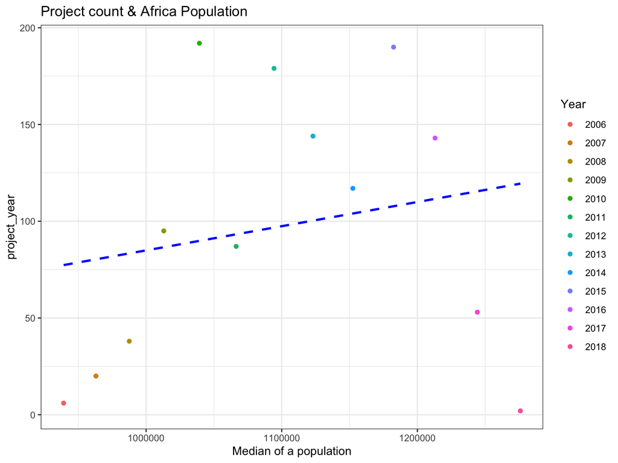

# 5.3.2 - Does international investment in food in African countries affect local GDP?

```
## # A tibble: 6 x 14
##   Country  `2006`  `2007`  `2008`  `2009`  `2010`  `2011`  `2012`  `2013`
##   <chr>     <dbl>   <dbl>   <dbl>   <dbl>   <dbl>   <dbl>   <dbl>   <dbl>
## 1 ARUBA   2.42e 9 2.62e 9 2.75e 9 2.50e 9 2.39e 9 2.55e 9 2.53e 9 2.58e 9
## 2 AFGHAN… 6.97e 9 9.75e 9 1.01e10 1.24e10 1.59e10 1.78e10 2.00e10 2.06e10
## 3 ANGOLA  5.24e10 6.53e10 8.85e10 7.03e10 8.38e10 1.12e11 1.28e11 1.37e11
## 4 ALBANIA 8.90e 9 1.07e10 1.29e10 1.20e10 1.19e10 1.29e10 1.23e10 1.28e10
## 5 ANDORRA 3.54e 9 4.02e 9 4.01e 9 3.66e 9 3.36e 9 3.44e 9 3.16e 9 3.28e 9
## 6 ARAB W… 1.40e12 1.64e12 2.08e12 1.80e12 2.11e12 2.50e12 2.79e12 2.87e12
## # … with 5 more variables: `2014` <dbl>, `2015` <dbl>, `2016` <dbl>,
## #   `2017` <dbl>, tot_gdp <dbl>
```

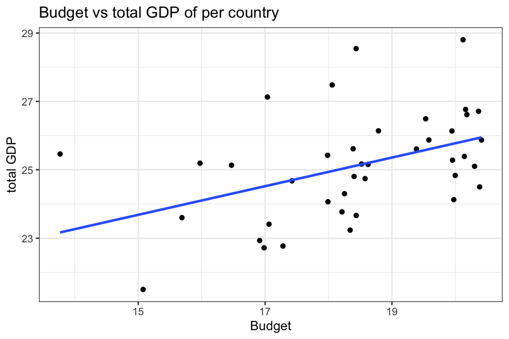

# 6 - Data-driven Hypotheses

# 6.1 - Here we want to test if our initial hypothesis is true (fail to reject) or not(reject)

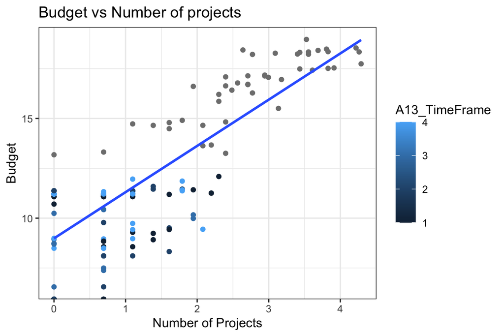

# 6.2 - Multiple regression on the hypothesis:

```
## # A tibble: 131 x 4
## # Groups:   Country [48]
##    Country      A13_TimeFrame Budget Number_of_project
##    <chr>                <dbl>  <dbl>             <dbl>
##  1 ANGOLA                   1  11.1              0.693
##  2 ANGOLA                  NA  16.6              1.95
##  3 BENIN                    1   9.29             1.10
##  4 BENIN                   NA  18.3              3.43
##  5 BOTSWANA                 2  11.4              0
##  6 BOTSWANA                NA  16.6              2.40
##  7 BURKINA FASO             1   8.57             0.693
##  8 BURKINA FASO             2  11.6              1.39
##  9 BURKINA FASO            NA  18.5              3.81
## 10 BURUNDI                  1   8.92             1.39
## # … with 121 more rows
```

```
##
## Call:
## lm(formula = A13_TimeFrame ~ Number_of_project + Budget, data = the_model)
##
## Residuals:
##      Min       1Q   Median       3Q      Max
## -1.91334 -1.25797 -0.01318  1.09562  2.03850
##
## Coefficients:
##                   Estimate Std. Error t value Pr(>|t|)
## (Intercept)        2.68104    1.05466   2.542   0.0129 *
## Number_of_project -0.44121    0.21857  -2.019   0.0468 *
## Budget             0.02096    0.10232   0.205   0.8382
## ---
## Signif. codes:  0 '***' 0.001 '**' 0.01 '*' 0.05 '.' 0.1 ' ' 1
##
## Residual standard error: 1.259 on 81 degrees of freedom
##   (47 observations deleted due to missingness)
## Multiple R-squared:  0.0479, Adjusted R-squared:  0.02439
## F-statistic: 2.037 on 2 and 81 DF,  p-value: 0.137
```

# 7 - Discussion

# 8 - References

- Breman, H., & Debrah, S. (2003). Improving African food security. *SAIS Review, 23(1), 153-170.*  
  *Artilce for our reference.*
- Food Safety in Africa: Past Endeavors and Future Directions.(2019, February 5). Retrieved from https://datacatalog.worldbank.org/dataset/food-safety-africa-past-endeavors-and-future-directions  
  *This data is the open-source from The World Bank Group collected. The Global Food Safety Partnership’s (GFSP) Food Safety in Africa provides an approach to illustrative information on 518 food safety investments in sub-Saharan Africa from 2010 to early 2017.*
- List of sovereign states and dependent territories in Africa. (2020, April 27). Retrieved from https://en.wikipedia.org/wiki/List_of_sovereign_states_and_dependent_territories_in_Africa  
  *Africa Countries renamed.*
- Lovelace, R., Nowosad, J., & Muenchow, J. (2020, April 21). Chapter 8: Making maps with R. Retrieved from https://geocompr.github.io/geocompkg/articles/solutions08.html  
  *How to create Africa map with the existing dataset.*
- Mwaniki, A. (2006). Achieving food security in Africa: Challenges and issues. *UN Office of the Special Advisor on Africa (OSAA).*  
  *Artilce for our reference.*
- New GFSP Report Quantifies Food Safety Investment in sub-Saharan Africa. (n.d.). Retrieved from https://www.gfsp.org/new-gfsp-report-quantifies-food-safety-investment-sub-saharan-africa  
  *Global Food Safety Partnership’s website was announced the official information for this data frame. We can download reading guide via this association.*
- UNdata | explorer. (n.d.). Retrieved from http://data.un.org/Explorer.aspx?d=PopDiv  
  *Get some quantitative data such as death rates or total population for the countries.*